# Analysis of Ford GoBike sharing service

## by Qudus Adeyemi

## Investigation Overview

> The purpose of this presentation is to disseminate business insights obtained from the Ford GoBike bike-sharing service. The important findings listed below will be conveyed in this presentation:
> - The users who spend the most time using the service
> - The people who use it the most frequently
> - The usage patterns on weekdays and weekends
> - The locations they frequent the most.

## Usage Pattern by duration and frequency

- Customers' usage habits continue to be the same over time, while subscribers' numbers are on the decline on the weekends but on the rise during the week.
- The customers spends more time on the service on weekends more than weekdays and in general they spend more time than the subscribers
- The subscribers spend more time on weekends, while their weekday usage remains consistent.

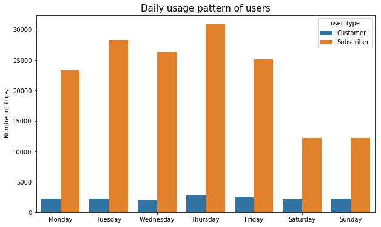

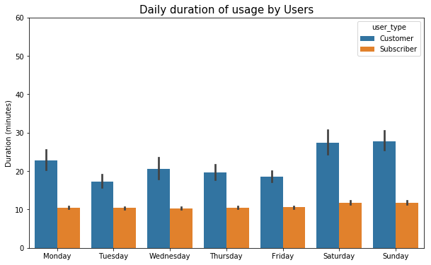

## Usage Frequency by user type

- About ten times as many subscribers use the service as customers do.

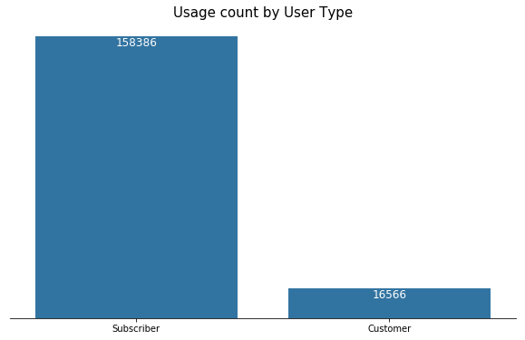

## Most Popular Origin Destination by User type

- The most popular origin destination for subscribers is Berry St at 4th St - San Francisco Ferry Building (Harry Bridges Plaza)
- The most popular origin destination for Customers is San Francisco Ferry Building (Harry Bridges Plaza) - The Embarcadero at Sansome St

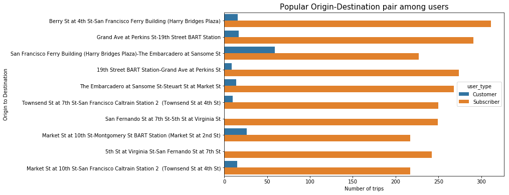